# NLP Report

José Antonio García Ramirez

December 22, 2017

```r
knitr::opts_chunk$set(echo = TRUE, cache = TRUE, warning = FALSE)
```

# Raw data

For our text analysis project, we have a set of data which is formed by three large files (sets of words) which are accessible from [here](https://web-beta.archive.org/web/20160930083655/http://www.corpora.heliohost.org/aboutcorpus.html).

After unzipping, you have the following

| File | Lines | Max length of line (characters) |
| --- | --- | --- |
| blogs | 899,288 | 40,833 |
| news | 77,259 | 5,760 |
| twitter | 2,360,148 | 140 |

For the objective we are looking for, we consider that including the files corresponding to *news* increases the statistical variance unnecessarily, so we will work with two models one with the three files and the second without considering the *news* ( *news* is much longer than what is written on a cell phone in addition to having a lexicon and tone very different from the other two files).

# Data wrangling

Following the work of [^1] we perform the following transformations to clean the data:

- Remove whitespaces, punctuation and numbers.
- Transform to lower letters
- Remove stop words like *a*, *an*, *by* …
- *stem* words

# How our words looks like?

## Current results

Using the data without having received the preprocessing to keep the root of the words we have:

- We need only 1,015 words to cover 50% of de freqs and 148,076 to cover 90% without stem

```r
wordcloud2(data = cloud2)
```

[interactive chart not shown]

- And we need only 666 words to cover 50% of de freqs and 117,747 to cover 90% with stem

```r
wordcloud2(data = cloud2)
```

[interactive chart not shown]

So we decided to continue with the stemed dataset and ngram algorithm

```r
ggplot(data = head(n_1grams,20), aes(x = factor(n_1grams), y = Freq, fill = Freq)) +
  geom_bar(stat="identity") +   # se construyen las barras
  scale_fill_distiller(palette = 'Accent')+ # la magia de poder escoger facÃ???l el color de la escala 'continua' o discreta
  xlab('Top 20') + theme_minimal() +  ggtitle('1-grams')+  #demas cosas
  guides(fill=FALSE) + #quitar leyenda
  coord_flip()
remove("n_1grams")
gc()
```

[output not shown]

### Top 20 2-gram

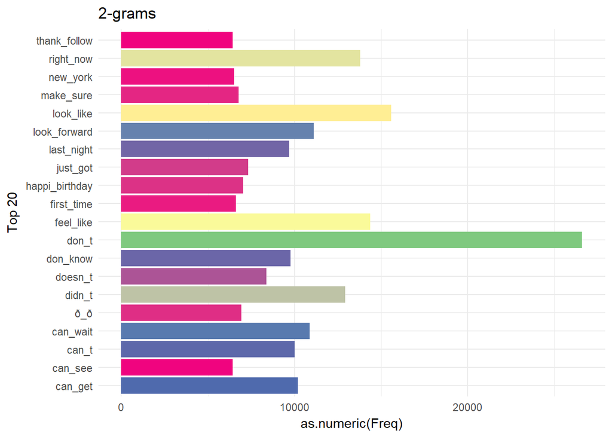

```r
ggplot(data = head(n_2grams,20), aes(x = paste(uno, dos ,sep='_'), y = as.numeric(Freq), fill = as.numeric(Freq))) +
  geom_bar(stat="identity") +   # se construyen las barras
  scale_fill_distiller(palette = 'Accent')+ # la magia de poder escoger facÃ???l el color de la escala 'continua' o discreta
  xlab('Top 20') + theme_minimal() +  ggtitle('2-grams')+  #demas cosas
  guides(fill=FALSE) + #quitar leyenda
  coord_flip()
```

```r
remove("n_2grams")
gc()
```

```
##            used  (Mb) gc trigger   (Mb)  max used   (Mb)
## Ncells  4915621 262.6    8273852  441.9   6861544  366.5
## Vcells 70597216 538.7  211337468 1612.4 160561495 1225.0
```

Up to this point all the Corpus is used, from here onwards for questions of capacity of the computation, the Corpus was divided into 20 parts, the n-grams were extracted (3 and 4) and only the gramswith frequency greater than one were saved.

### Top 20 3-gram

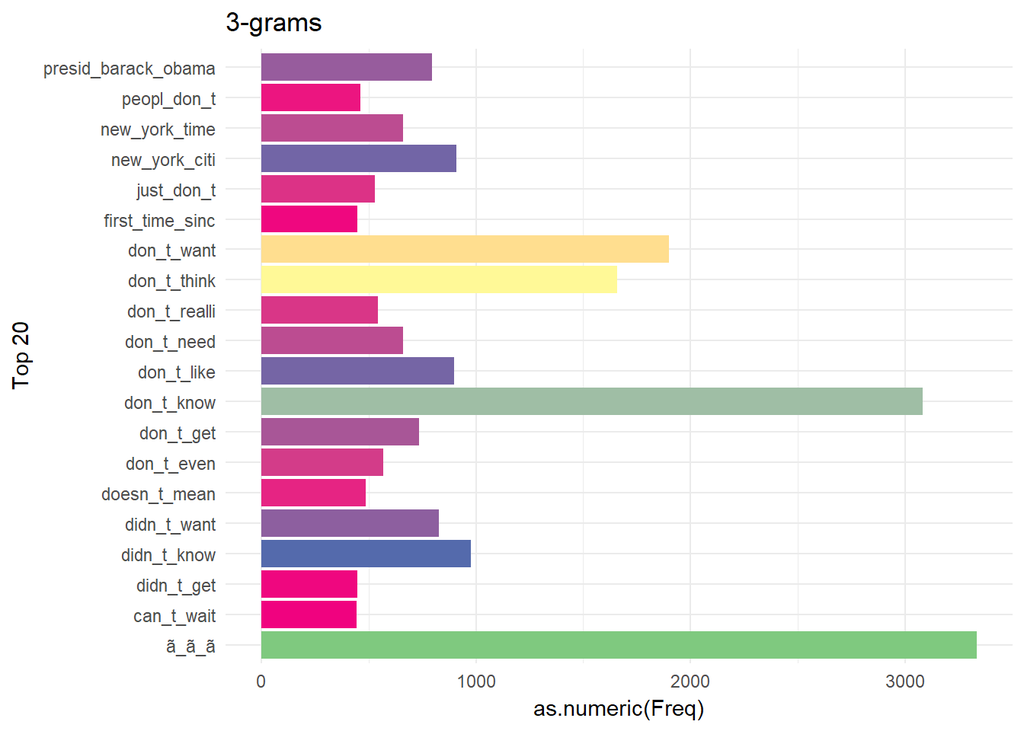

```r
n_3grams <- readRDS( file = "C:\\Users\\fou-f\\Desktop\\R-Coursera\\NLP\\project\\n_3grams_app.RDS")
n_3grams <- n_3grams[order(as.numeric(n_3grams$Freq), decreasing = TRUE), ]
ggplot(data = head(n_3grams,20), aes(x = paste(uno,dos,tres, sep = '_') , y = as.numeric(Freq), fill = as.numeric(Freq))) +
  geom_bar(stat="identity") +   # se construyen las barras
  scale_fill_distiller(palette = 'Accent')+ # la magia de poder escoger facÃ???l el color de la escala 'continua' o discreta
  xlab('Top 20') + theme_minimal() +  ggtitle('3-grams')+  #demas cosas
  guides(fill=FALSE) + #quitar leyenda
  coord_flip()
```

```r
remove("n_3grams")
gc()
```

```
##            used  (Mb) gc trigger   (Mb)  max used   (Mb)
## Ncells  4934942 263.6    8273852  441.9   8273852  441.9
## Vcells 70660290 539.1  211337468 1612.4 160561495 1225.0
```

### Top 20 4-gram

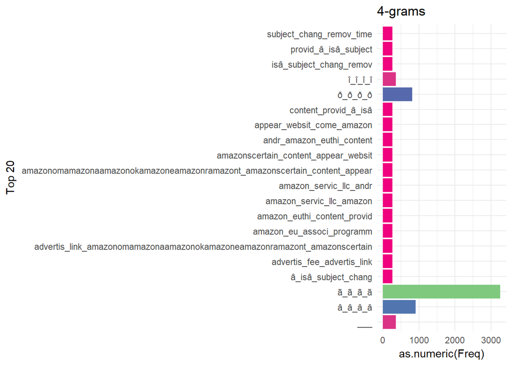

```r
ggplot(data = head(n_4grams,20), aes(x = paste(uno, dos, tres, cuatro, sep='_'), y = as.numeric(Freq), fill = as.numeric(Freq))) +
  geom_bar(stat="identity") +   # se construyen las barras
  scale_fill_distiller(palette = 'Accent')+ # la magia de poder escoger facÃ???l el color de la escala 'continua' o discreta
  xlab('Top 20') + theme_minimal() +  ggtitle('4-grams')+  #demas cosas
  guides(fill=FALSE) + #quitar leyenda
  coord_flip()
```

```r
remove("n_4grams")
gc()
```

```
##            used  (Mb) gc trigger   (Mb)  max used   (Mb)
## Ncells  4939440 263.8    8273852  441.9   8273852  441.9
## Vcells 70671562 539.2  211337468 1612.4 160561495 1225.0
```

[^1]: Pengda Qin, Weiran Xu and Jun Guo, ‘A Targeted Retraining Scheme of Unsupervised Word Embeddings for Specific Supervised Tasks,’ in Advances in Knowledge Discovery and Data Mining 2017, Springer.